# Demo Decision Tree (EVPPI)

Home page

This model was developed by Philippe Beutels and Joke Bilcke, for illustration and teaching purposes only. Please make contact if you would like to use this model in any public way.

In the field of economic evaluation in general, it could be applicable to any intervention with effectiveness realised within one year (like many curative interventions). In the field of infectious disease, it would only be applicable to influenza, and only if vacccination targets a small proportion of the population that does not at the same time form a core transmitter group of the virus (eg it is unlikely to be suitable to model childhood influenza vaccination). Note that for most applications, practical use of this model would likely entail having separate, though similarly simple decision trees to obtain the unit cost estimates (implying that these cells would be intermediary outcomes, and that there would be additional input cells for each relevant stage of disease (for instance for the number of consultations, the unit costs per consultation, medication use, hospital days etc for cases of pneumonia, and all other relevant disease stages)).

Note that the final output is independent of coverage and target group size, if fixed administration costs are set to 0. This is due to the exclusion of herd immunity effects in this model.

For further information, questions or comments please contact: philippe.beutels@uantwerp.be or joke.bilcke@uantwerp.be Centre for Health Economics Research and Modeling of Infectious Diseases (CHERMID) Vaccine and Infectious Disease Institute (Vaxinfectio) University of Antwerp Universiteitsplein 1 2610 Antwerp Belgium

# Set working directory

The first step when creating a new R file is to specify a working directory. You need to tell the R session where you want it to work. To do this you use the command to “set the working directory” or `setwd()`.

You can label this working directory as ‘home’, and have other locations stored for plotting or for getting data. This location should be an existing folder on your computer. For example

```r
home <- "~/Documents/Modelling_intro/" ## on a OS X
home <- "C:\\Documents\\Modelling_intro\\" ## on windows
setwd(home)
```

# load packages

If BCEA package is not installed yet, you can do so by

```r
install.packages('BCEA')
```

Once installed, you have to load the package(s) at the start of the R file. This is done using

```r
library(BCEA)
```

# Set number of samples

```r
Nsamples<-5000
```

# Input

```r
set.seed(698) # use this to get exactly the same results each time you run the code (e.g. for code checking)
targetgroup<-2500000                                #people>65 years
uptake_program<-0.80
force_of_infection<-rbeta(Nsamples,4,96)    #draw Nsamples randomly from a beta distribution with parameters 4 and 96
proportion_hospitalised<-rbeta(Nsamples,10,90)
casefatality_ratio<-rbeta(Nsamples,30,970)
life_expectancy<-rnorm(Nsamples,mean=12,sd=2)               #in years
vaccine_efficacy<-rnorm(Nsamples,mean=0.6,sd=(0.7-0.5)/(2*1.96))
vaccineprice_perdose<-10                            #dollars
administrationcosts_perdose<-rnorm(Nsamples,50,4)           #dollars
cost_per_hospitalised_case<-rnorm(Nsamples,2000,100)            #dollars
cost_per_nonhospitalised_case<-rnorm(Nsamples,100,5)            #dollars
fixed_program_costs<-0                              #dollars
QALYslost_per_hospitalised_case<-rnorm(Nsamples,mean=0.018,sd=0.0018)
    alphaqalynonhosp=(0.0082^2*(1-0.0082)/0.0018^2)-0.0082
QALYslost_per_nonhospitalised_case<-rbeta(Nsamples,alphaqalynonhosp,alphaqalynonhosp*(1-0.0082)/0.0082)
discountrate<-0.015
```

# Intermediary output

```r
variable_vaccinationcost_perdose<-vaccineprice_perdose+administrationcosts_perdose
treatment_costs_per_case<-cost_per_hospitalised_case*proportion_hospitalised+(1-proportion_hospitalised)*cost_per_nonhospitalised_case
QALYslost_per_case<-QALYslost_per_hospitalised_case*proportion_hospitalised+(1-proportion_hospitalised)*QALYslost_per_nonhospitalised_case
discounted_life_expectancy<-rep(NA,Nsamples)
for (i in 1:Nsamples)
{discounted_life_expectancy[i]<-sum(1/((1+discountrate)^(1:life_expectancy[i])))}

#Program
program_infections<-targetgroup*uptake_program*force_of_infection*(1-vaccine_efficacy)+targetgroup*(1-uptake_program)*force_of_infection
program_hospitalisations<-program_infections*proportion_hospitalised
program_deaths<-program_infections*casefatality_ratio
program_lifeyearslost<-program_deaths*discounted_life_expectancy
program_QALYslost<-program_infections*QALYslost_per_case+program_lifeyearslost

program_treatmentcosts<-program_infections*treatment_costs_per_case
program_vaccinationcosts<-ifelse(uptake_program!=0,targetgroup*uptake_program*variable_vaccinationcost_perdose+fixed_program_costs,targetgroup*uptake_program*varaible_vaccinationcost_perdose)
program_totaldirectcosts<-program_treatmentcosts+program_vaccinationcosts

#No Program
noprogram_infections<-targetgroup*force_of_infection
noprogram_hospitalisations<-noprogram_infections*proportion_hospitalised
noprogram_deaths<-noprogram_infections*casefatality_ratio
noprogram_lifeyearslost<-noprogram_deaths*discounted_life_expectancy
noprogram_QALYslost<-noprogram_infections*QALYslost_per_case+noprogram_lifeyearslost

noprogram_treatmentcosts<-noprogram_infections*treatment_costs_per_case
noprogram_vaccinationcosts<-0
noprogram_totaldirectcosts<-noprogram_treatmentcosts+noprogram_vaccinationcosts

#Difference between 'program' and 'no program' (events and costs averted)
diff_infections1.5<-noprogram_infections-program_infections
diff_hospitalisations1.5<-noprogram_hospitalisations-program_hospitalisations
diff_deaths1.5<-noprogram_deaths-program_deaths
diff_lifeyearslost1.5<-noprogram_lifeyearslost-program_lifeyearslost
diff_QALYslost1.5<-noprogram_QALYslost-program_QALYslost

diff_treatmentcosts1.5<-noprogram_treatmentcosts-program_treatmentcosts
diff_vaccinationcosts1.5<-noprogram_vaccinationcosts-program_vaccinationcosts
diff_totaldirectcosts1.5<--(diff_treatmentcosts1.5+diff_vaccinationcosts1.5)
```

# Cost-effectiveness output (using the BCEA package)

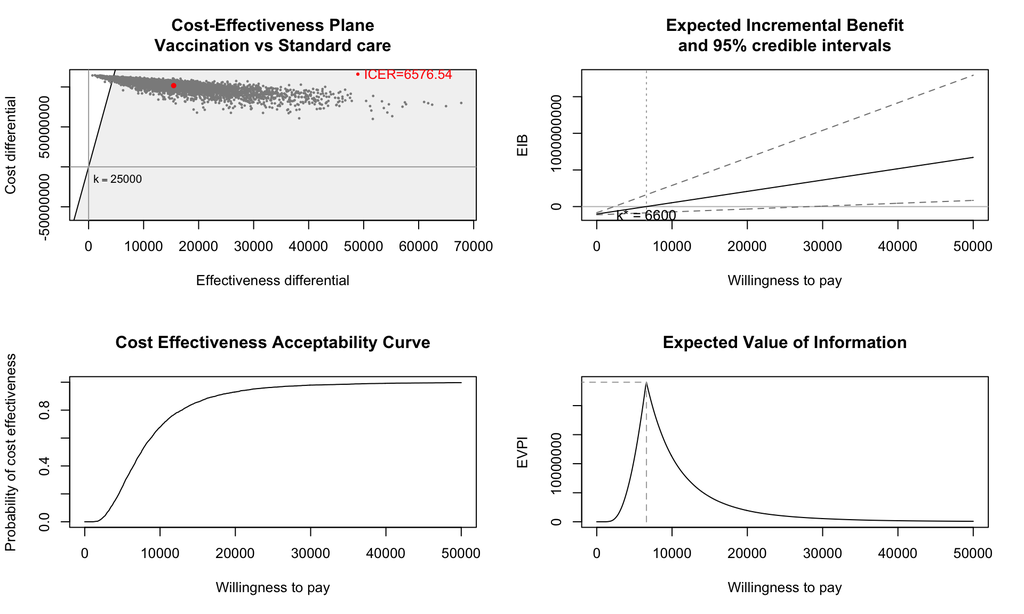

```r
#Prepare and run the function
c=cbind(noprogram_totaldirectcosts,program_totaldirectcosts)
e=cbind(-noprogram_QALYslost,-program_QALYslost) ##negative sign because input needs to be health gain (and we are loosing health due to flu)
ints=c("Standard care","Vaccination")
m <- bcea(e,c,ref=2,interventions=ints,plot=T) #ref specifies to compare 'Vaccination' to 'Standard care'
```

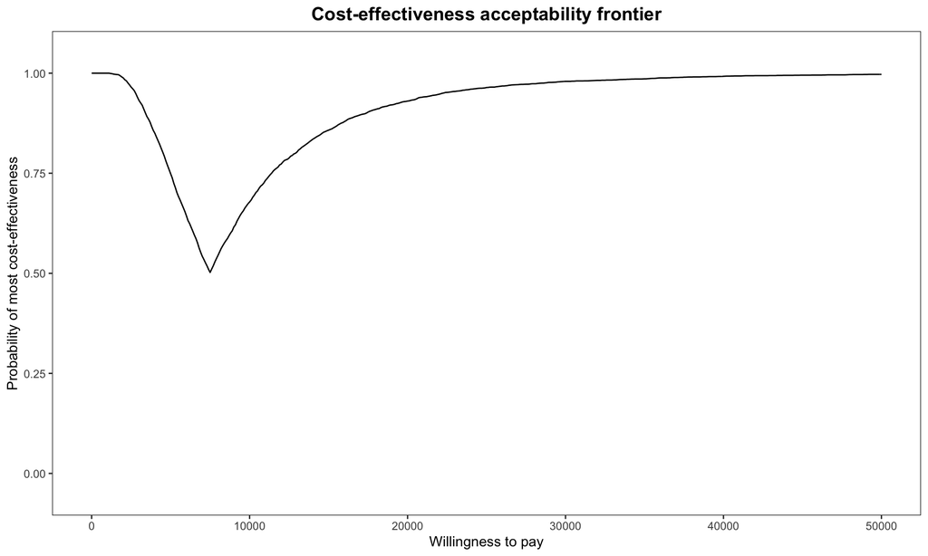

```r
#Generate output
### 1. Cost-effectiveness plane --> see plots
### 2. Which decision should I take, given current information and for a range of WTP values?
        #--> see plots cost-effectiveness plane and expected incremental benefit
        #--> see summary: 'optimal decision' and 'Vaccination vs Standard care'
        summary(m)
        #--> or calculate manually:
        mean(diff_totaldirectcosts1.5)/mean(diff_QALYslost1.5) #average ICER
        k=25000
        mean((diff_QALYslost1.5*k)-diff_totaldirectcosts1.5)#average INMB for k
        #--> average INMB of vaccination compared to standard care, for the range of WTP values considered
        m$eib
### 3. How much evidence is there in favor of the decision, for a range of WTP values
        #--> see plot cost-effectiveness acceptability curve
        #--> see summary 'Vaccination vs Standard care: CEAC'
        summary(m)
        #--> construct a cost-effectiveness acceptability frontier plot
        m_ceaf<-multi.ce(m)
        ceaf.plot(m_ceaf,graph='ggplot2') #but no color used?
```

```r
        #data needed to construct CEAC and CEAF plots
        m_ceafceac=cbind(m$k,ints[m$best],m$ceac)
        colnames(m_ceafceac)=c('wtp value','optimal decision','probability highest INMB ref')

### 4. Is there value in further research?
        #--> see Expected Value of Information plot
        #--> see summary 'EVPI'
        summary(m)
        #data needed to construct EVPI plot:
        m_evpi=cbind(m$k,m$evi)
        colnames(m_evpi)=c('wtp value','evpi')
```

# Assess importance measures: EVPPI

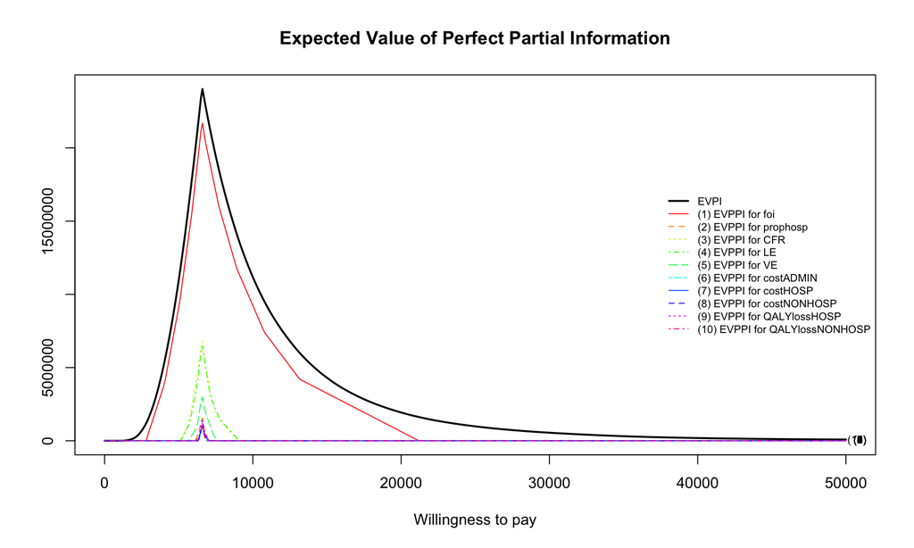

```r
#combine all uncertain input parameters in a single dataset
uncinput=cbind(force_of_infection,proportion_hospitalised,casefatality_ratio,life_expectancy,vaccine_efficacy,administrationcosts_perdose,
               cost_per_hospitalised_case,cost_per_nonhospitalised_case,QALYslost_per_hospitalised_case,
               QALYslost_per_nonhospitalised_case)
uncinputnames=c('foi','prophosp','CFR','LE','VE','costADMIN','costHOSP','costNONHOSP','QALYlossHOSP','QALYlossNONHOSP')
colnames(uncinput)=uncinputnames
#run the evppi function (need to have run the bcea function before)
m_evppi=evppi(parameter=uncinputnames,input=uncinput,he=m,method='so',n.blocks=10)
plot.evppi(m_evppi,pos='right',col=rainbow(ncol(uncinput)))
```

```r
#data to construct EVPPI plot
m_evppi$evppi
```

# Navigate

Top: Index